# K-Nearest Neightboor

KNN is a specific model which do not use parameter (and statistics). It's a supervised model which is aimed to classify dataset.

The only thing we are going to choose is k, the number of nearest-neightboor from one point. K is called a hyperparameter.

In order to understand the exercice, make sure to visit the following website, where this exercise was found : https://openclassrooms.com/fr/courses/4011851-initiez-vous-au-machine-learning/4022441-entrainez-votre-premier-k-nn

The global aim is to correctly classify wrote and annoted number.

For this purpose, we will be using the MNIST's dataset, store in Sklearn library.

```python
# Import libraries
import math
import numpy as np
import pandas as pd
import matplotlib.pyplot as plt
from sklearn import neighbors
from sklearn.datasets import fetch_openml
from sklearn.model_selection import train_test_split
import seaborn as sns
from pylab import *
```

```python
# load dataset and convert to pandas dataframe
data = fetch_openml('mnist_784', version=1)
MNIST = pd.DataFrame(data= np.c_[data['data'], data['target']],
                     columns= data['feature_names'] + ['target'])
```

```python
MNIST.head()
```

|  | pixel1 | pixel2 | pixel3 | pixel4 | pixel5 | pixel6 | pixel7 | pixel8 | pixel9 | pixel10 | ... | pixel776 | pixel777 | pixel778 | pixel779 | pixel780 | pixel781 | pixel782 | pixel783 | pixel784 | target |
| --- | --- | --- | --- | --- | --- | --- | --- | --- | --- | --- | --- | --- | --- | --- | --- | --- | --- | --- | --- | --- | --- |
| 0 | 0 | 0 | 0 | 0 | 0 | 0 | 0 | 0 | 0 | 0 | ... | 0 | 0 | 0 | 0 | 0 | 0 | 0 | 0 | 0 | 5 |
| 1 | 0 | 0 | 0 | 0 | 0 | 0 | 0 | 0 | 0 | 0 | ... | 0 | 0 | 0 | 0 | 0 | 0 | 0 | 0 | 0 | 0 |
| 2 | 0 | 0 | 0 | 0 | 0 | 0 | 0 | 0 | 0 | 0 | ... | 0 | 0 | 0 | 0 | 0 | 0 | 0 | 0 | 0 | 4 |
| 3 | 0 | 0 | 0 | 0 | 0 | 0 | 0 | 0 | 0 | 0 | ... | 0 | 0 | 0 | 0 | 0 | 0 | 0 | 0 | 0 | 1 |
| 4 | 0 | 0 | 0 | 0 | 0 | 0 | 0 | 0 | 0 | 0 | ... | 0 | 0 | 0 | 0 | 0 | 0 | 0 | 0 | 0 | 9 |

5 rows × 785 columns

## Exploring the data

As we can see, the dataset is mainly compounded of 784 columns which represents every pixel in a 28*28 pixels image and the "target" column meaning the labeled number which corresponds to the image.

We will try to firstly represents data by group of label, in order to see patterns.

```python
count = pd.DataFrame(MNIST["target"].value_counts()).sort_index()
classNumber = count.shape[0]
print("Class number : {}".format(classNumber))
```

```
Class number : 10
```

We correctly get 10 classes (0 to 9). We now want to see the repartition of the data.

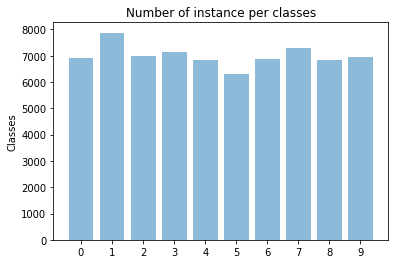

```python
y_pos = np.arange(classNumber)
data = list(count["target"])
plt.bar(y_pos, data, align='center', alpha=0.5)
plt.xticks(y_pos, list(count.index))
plt.ylabel('Classes')
plt.title('Number of instance per classes')
rcParams['figure.figsize'] = (12, 8)
plt.show()
```

```python
print("Count :\n   Mean : {}\n   Median : {}".format(count["target"].mean(),count["target"].median()))
```

```
Count :
   Mean : 7000.0
   Median : 6930.5
```

We see that the data set is well ramified over different classes, then our algorithm should be good on the whole classes.

```python
# processing data, aggregating each class in a specified dataframe, contained in a list
classes = [MNIST[MNIST["target"] == str(i)] for i in range(0, classNumber)]
```

```python
# for each class, count the number of time the pixel was seen
pixel_count_classes = []
for i in range(0, len(classes)):
    l = list(classes[i].columns)
    temp = []
    for column in range(0, len(l)-1):
        temp.append(classes[i][classes[i][l[column]] != 0].count()[l[column]])
    pixel_count_classes.append(temp)
```

```python
# for each class, divide each value by the total row count
pixel_freq_classes = []
for i in range(0, len(pixel_count_classes)):
    pixel_freq_classes.append(pixel_count_classes[i]/classes[i]["target"].count())
```

```python
# for each class, create a numpy matrix representing the heathmap
M_classes = []
for k in range(0, len(pixel_freq_classes)):
    sqrt = int(math.sqrt(len(pixel_freq_classes[k])))
    M_classes.append(np.asmatrix(np.array([[pixel_freq_classes[k][sqrt * i + j] for j in range(0, sqrt)] for i in range(0, sqrt)])))
```

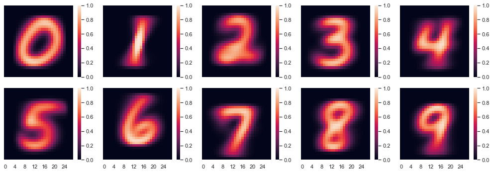

```python
sns.set(style="white", palette="muted", color_codes=True)
rs = np.random.RandomState(10)

# Set up the matplotlib figure
line = 2 if len(M_classes)%2 == 0 else 1
f, axes = plt.subplots(2, 5, figsize=(14, 5), sharex=True)
sns.despine(left=True)
for i in range(0, len(M_classes)):
    # draw the heathmap
    sns.heatmap(M_classes[i], vmin=0, vmax=1, annot=False, ax=axes[int(i/5),i%5])
plt.setp(axes, yticks=[])
plt.tight_layout()
plt.show()
```

We can see that the distribution of pixel is really constant regarding to each number.

## Training - Testing a simple Model

Now, we have to train our KNN model in order to predict correct labels.

Firstly we will have to reduce the amount of data in order to quickly test our ideas by sampling the Dataframe.

```python
df = MNIST.sample(frac=1/10)
df.head()
```

|  | pixel1 | pixel2 | pixel3 | pixel4 | pixel5 | pixel6 | pixel7 | pixel8 | pixel9 | pixel10 | ... | pixel776 | pixel777 | pixel778 | pixel779 | pixel780 | pixel781 | pixel782 | pixel783 | pixel784 | target |
| --- | --- | --- | --- | --- | --- | --- | --- | --- | --- | --- | --- | --- | --- | --- | --- | --- | --- | --- | --- | --- | --- |
| 48362 | 0 | 0 | 0 | 0 | 0 | 0 | 0 | 0 | 0 | 0 | ... | 0 | 0 | 0 | 0 | 0 | 0 | 0 | 0 | 0 | 6 |
| 63936 | 0 | 0 | 0 | 0 | 0 | 0 | 0 | 0 | 0 | 0 | ... | 0 | 0 | 0 | 0 | 0 | 0 | 0 | 0 | 0 | 7 |
| 8819 | 0 | 0 | 0 | 0 | 0 | 0 | 0 | 0 | 0 | 0 | ... | 0 | 0 | 0 | 0 | 0 | 0 | 0 | 0 | 0 | 5 |
| 28703 | 0 | 0 | 0 | 0 | 0 | 0 | 0 | 0 | 0 | 0 | ... | 0 | 0 | 0 | 0 | 0 | 0 | 0 | 0 | 0 | 4 |
| 41103 | 0 | 0 | 0 | 0 | 0 | 0 | 0 | 0 | 0 | 0 | ... | 0 | 0 | 0 | 0 | 0 | 0 | 0 | 0 | 0 | 1 |

5 rows × 785 columns

```python
Y = pd.DataFrame(df["target"])
X = df.drop(labels="target", axis=1)
X_train, X_test, Y_train, Y_test = train_test_split(X, Y, test_size=0.2)
print("Training set count X:{}/Y:{}, Test set count X:{}/Y:{}".format(
    int(X_train.shape[0]), int(Y_train.shape[0]), int(X_test.shape[0]), int(Y_test.shape[0])))
```

```
Training set count X:5600/Y:5600, Test set count X:1400/Y:1400
```

```python
knn = neighbors.KNeighborsClassifier(n_neighbors=3)
knn.fit(X_train, Y_train["target"])
```

```
KNeighborsClassifier(algorithm='auto', leaf_size=30, metric='minkowski',
                     metric_params=None, n_jobs=None, n_neighbors=3, p=2,
                     weights='uniform')
```

```python
print('Score : {}'.format(knn.score(X_test, Y_test)))
```

```
Score : 0.9428571428571428
```

## Optimizing the model

As we said in the beginning, we now have to optimize our model by changing our hyperparameter and finding the best k.

```python
result = pd.DataFrame(columns=['scores'])
for k in range(2, 10):
    knn = neighbors.KNeighborsClassifier(n_neighbors=k)
    knn.fit(X_train, Y_train["target"])
    result = result.append({'scores': knn.score(X_test, Y_test)}, ignore_index=True)
```

```python
result
```

|  | scores |
| --- | --- |
| 0 | 0.917857 |
| 1 | 0.942857 |
| 2 | 0.932857 |
| 3 | 0.937143 |
| 4 | 0.937143 |
| 5 | 0.949286 |
| 6 | 0.941429 |
| 7 | 0.937143 |

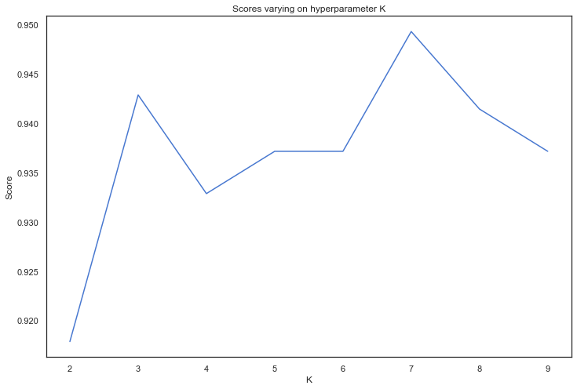

```python
ax = sns.lineplot(x=result.index+2, y=result["scores"])
ax.set_title('Scores varying on hyperparameter K')
ax.set_ylabel('Score')
ax.set_xlabel('K')
plt.show()
```

Here the best K is clearly 7. Then our model is able to reach a really great performance of 0.95 on the test set.